# IE 360 - HW 2

Irmak Dai

May 7, 2021

# 1 Introduction

The aim of this homework to apply time series regression on a macroeconomic indicator. The last digit of my student ID is “2”, so my target variable is the consumer price index for alcoholic beverages and tobacco. After building the model, I will provide a forecast of CPI for alcoholic beverages and tobacco of April 2021, so the monthly data up to April 2021 will be used. Also, I will use other predictors to improve the forecast. All the data will be obtained from [EVDS](https://evds2.tcmb.gov.tr/index.php?/evds/serieMarket).

As independent predictors, I decided to use USD/TRY exchange rate because I believe it has a significant impact on almost all macroeconomic indicators of Turkey. Also, another statistics that I think might be relevant are the import statistics of unprocessed and processed materials of food and beverages. From the survey statistics of [EVDS](https://evds2.tcmb.gov.tr/index.php?/evds/serieMarket), I will use general economic situation, which I think may be related.

# 2 Analysis

## 2.1 Loading the data & preparation

Loading the required packages:

```r
library(EVDS)
library(zoo)
library(lubridate)
library(dplyr)
library(ggplot2)
library(forecast)
library(GGally)
library(data.table)
Sys.setlocale("LC_TIME", "English")
```

I decided start date as 2013 because prior to 2013 most of the regressors that I want to use do not have the data. Also, I thought 8 years of data would be enough to come up with a good prediction.

```r
data <- get_series(series = c("TP.FG.J02","TP.TG2.Y04","TP.TG2.Y11","TP.DK.USD.A.YTL","TP.ITHALATBEC.121","TP.ITHALATBEC.111"), start_date = "01-01-2013", end_date = "01-03-2021")
df <- data$items[,-8]
df1 <- df %>%
  mutate(Date=as.yearmon(Tarih, "%Y-%m"),
         cpi_alcohol_tobacco=as.numeric(TP_FG_J02),
         general_economic_situation=as.numeric(TP_TG2_Y04),
         USD_TRY=as.numeric(TP_DK_USD_A_YTL),
         import_processed_food_beverage=as.numeric(TP_ITHALATBEC_121),
         import_unprocessed_food_beverage=as.numeric(TP_ITHALATBEC_111)) %>%
  select(Date:import_unprocessed_food_beverage)
```

## 2.2 Target variable

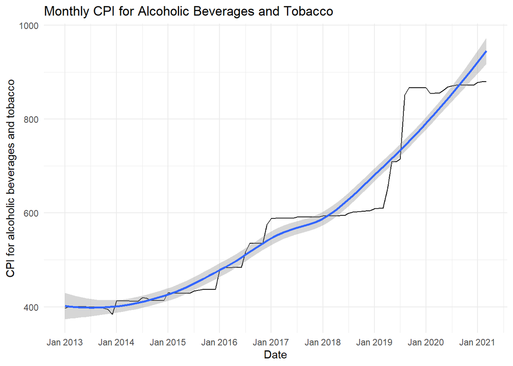

```r
ggplot(df1, aes(x=Date,y=cpi_alcohol_tobacco))+
  geom_line()+
  theme_minimal()+
  labs(y="CPI for alcoholic beverages and tobacco", title = "Monthly CPI for Alcoholic Beverages and Tobacco")+
  scale_x_yearmon(n=10)+
  geom_smooth()
```

From my point of view, CPI for alcohol and tobacco mostly depends on tax increases, instead of raw material and processing costs. So before starting my analysis, I anticipated to see periodic increases, especially in the beginning of each year. I was not wrong, but also there are increases in other months, which I think is surprising.

We see a clear increasing trend, so trend component should be included in the model. Although we did not see an obvious seasonality, it is observed that there are subsequent sharp increases with similar periods in between. So it would be nicer if month columns are added and included in the model.

Also, I noticed that smoothed line has a slightly exponential trend. That is why I thought taking the logarithm of the target variable could be a great idea.

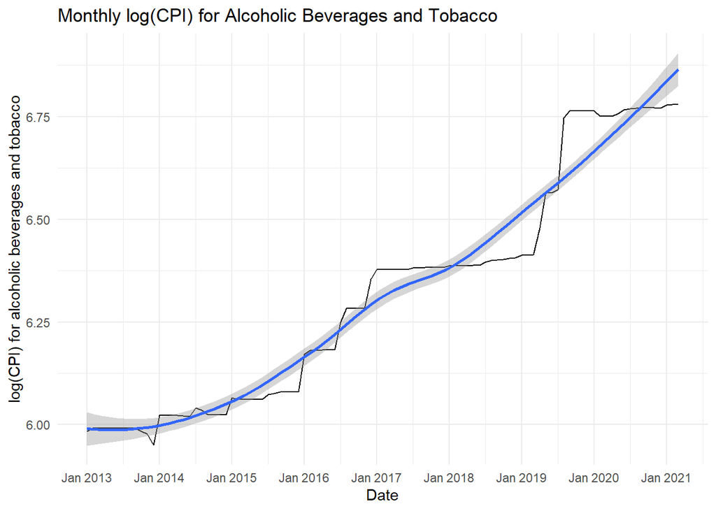

```r
df1 <- df1 %>%
  mutate(log_target=log(cpi_alcohol_tobacco))

ggplot(df1, aes(x=Date,y=log_target))+
  geom_line()+
  theme_minimal()+
  labs(y="log(CPI) for alcoholic beverages and tobacco", title = "Monthly log(CPI) for Alcoholic Beverages and Tobacco")+
  scale_x_yearmon(n=10)+
  geom_smooth()
```

## 2.3 Candidate regressors

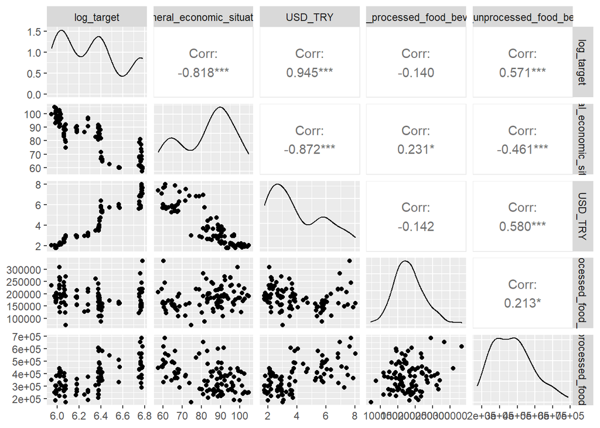

```r
ggpairs(df1, columns = c(7,3:6))
```

Our target variable is more or less correlated with regressor variables. Except the import statistics of processed food and beverages, all regressors have significant correlation with the target variable.

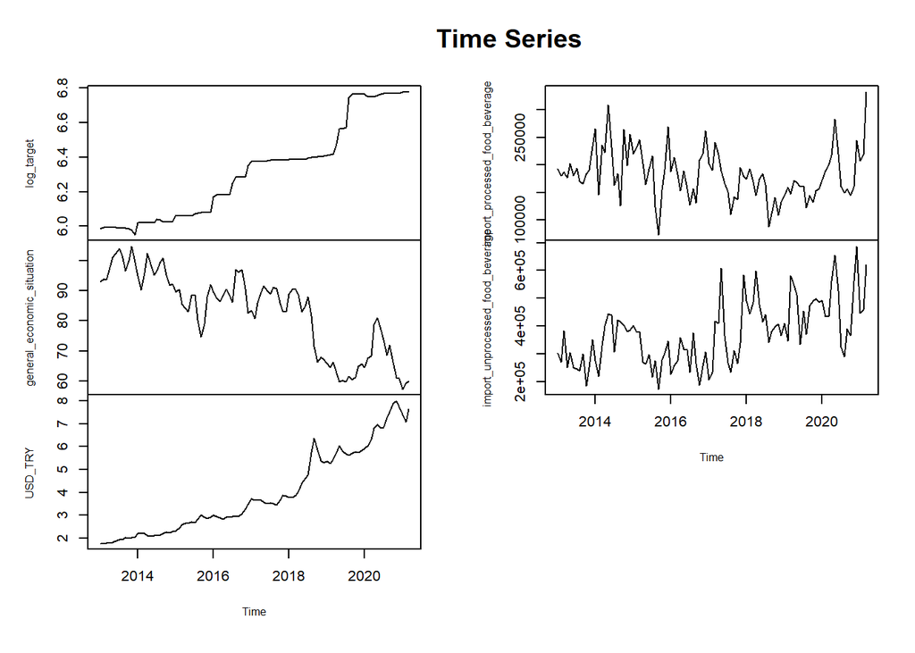

```r
ts <- ts(df1[,c(7,3:6)], start=c(2013,1), frequency=12)
plot(ts, cex.lab=0.5, main="Time Series")
```

## 2.4 Model building

### 2.4.1 Trial 1

Firstly, I will try a very simple model to see how it performs.

```r
df1 <- df1 %>%
  mutate(trend=c(1:nrow(df1)))

model1 <- lm(log_target ~ trend, df1)
summary(model1)
```

```
##
## Call:
## lm(formula = log_target ~ trend, data = df1)
##
## Residuals:
##       Min        1Q    Median        3Q       Max
## -0.141969 -0.053867 -0.001093  0.049561  0.152993
##
## Coefficients:
##              Estimate Std. Error t value Pr(>|t|)
## (Intercept) 5.8531005  0.0144164  406.00   <2e-16 ***
## trend       0.0093641  0.0002503   37.41   <2e-16 ***
## ---
## Signif. codes:  0 '***' 0.001 '**' 0.01 '*' 0.05 '.' 0.1 ' ' 1
##
## Residual standard error: 0.07118 on 97 degrees of freedom
## Multiple R-squared:  0.9352, Adjusted R-squared:  0.9345
## F-statistic:  1399 on 1 and 97 DF,  p-value: < 2.2e-16
```

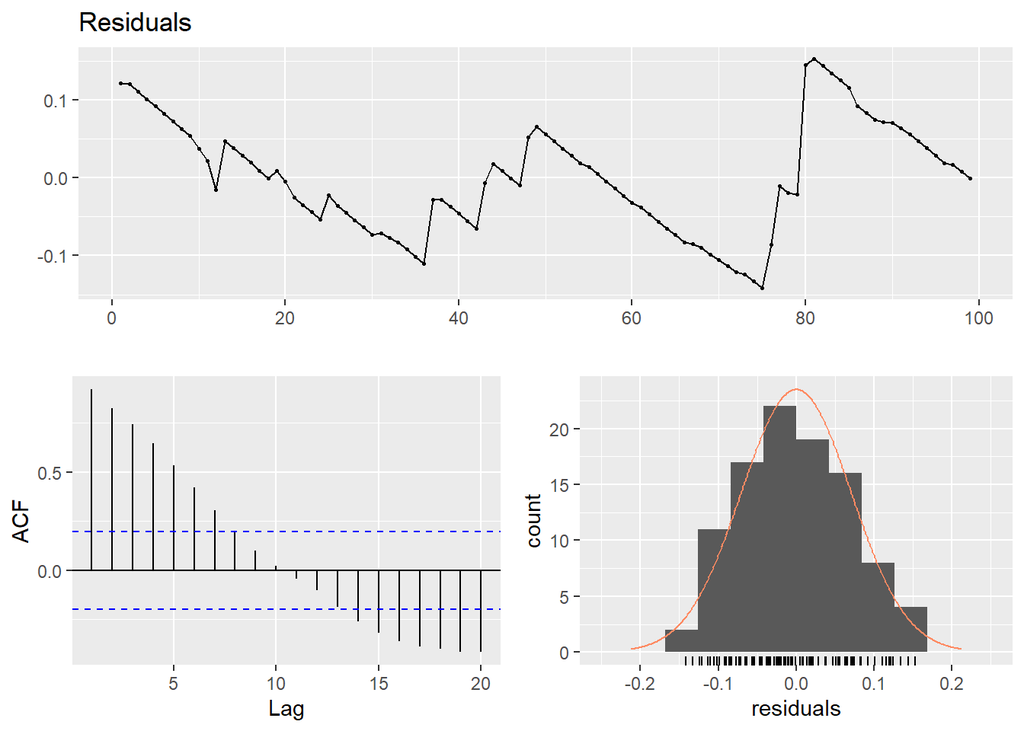

```
##
##  Breusch-Godfrey test for serial correlation of order up to 10
##
## data:  Residuals
## LM test = 84.935, df = 10, p-value = 5.376e-14
```

```r
checkresiduals(model1)
```

Although R-squared value is quite good (0.93), residuals are highly autocorrelated and their variance is not constant.

### 2.4.2 Trial 2

Adding the month columns to be used as factor in our model.

```r
df1 <- df1 %>%
  mutate( month=month(Date))
model2 <- lm(log_target~+trend+as.factor(month), df1)
summary(model2)
```

```
##
## Call:
## lm(formula = log_target ~ +trend + as.factor(month), data = df1)
##
## Residuals:
##      Min       1Q   Median       3Q      Max
## -0.14174 -0.05520 -0.00017  0.04466  0.14744
##
## Coefficients:
##                     Estimate Std. Error t value Pr(>|t|)
## (Intercept)         5.869676   0.028099 208.895   <2e-16 ***
## trend               0.009374   0.000264  35.509   <2e-16 ***
## as.factor(month)2  -0.008986   0.035277  -0.255    0.800
## as.factor(month)3  -0.018302   0.035280  -0.519    0.605
## as.factor(month)4  -0.019330   0.036371  -0.531    0.596
## as.factor(month)5  -0.017265   0.036366  -0.475    0.636
## as.factor(month)6  -0.025569   0.036363  -0.703    0.484
## as.factor(month)7  -0.019984   0.036362  -0.550    0.584
## as.factor(month)8  -0.002558   0.036363  -0.070    0.944
## as.factor(month)9  -0.010503   0.036366  -0.289    0.773
## as.factor(month)10 -0.020597   0.036371  -0.566    0.573
## as.factor(month)11 -0.030519   0.036377  -0.839    0.404
## as.factor(month)12 -0.034261   0.036386  -0.942    0.349
## ---
## Signif. codes:  0 '***' 0.001 '**' 0.01 '*' 0.05 '.' 0.1 ' ' 1
##
## Residual standard error: 0.07483 on 86 degrees of freedom
## Multiple R-squared:  0.9365, Adjusted R-squared:  0.9276
## F-statistic: 105.6 on 12 and 86 DF,  p-value: < 2.2e-16
```

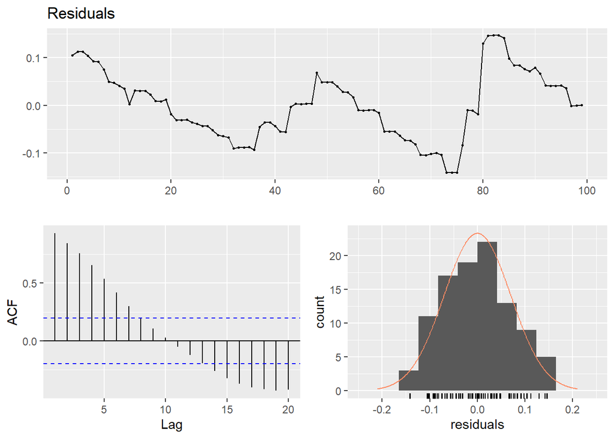

```
##
##  Breusch-Godfrey test for serial correlation of order up to 16
##
## data:  Residuals
## LM test = 87.859, df = 16, p-value = 6.192e-12
```

```r
checkresiduals(model2)
```

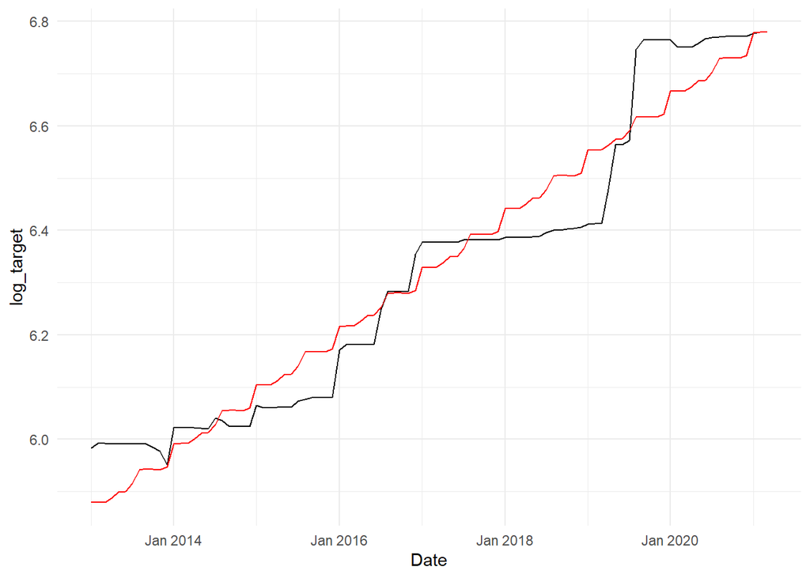

```r
ggplot(df1)+
  geom_line(aes(x=Date, y=log_target))+
  geom_line(aes(x=Date, y=predict(model2, df1)),color="red")+
  theme_minimal()
```

Again, we see that errors are autocorrelated, which implies when an error is made, the error is likely to continue further.

### 2.4.3 Trial 3

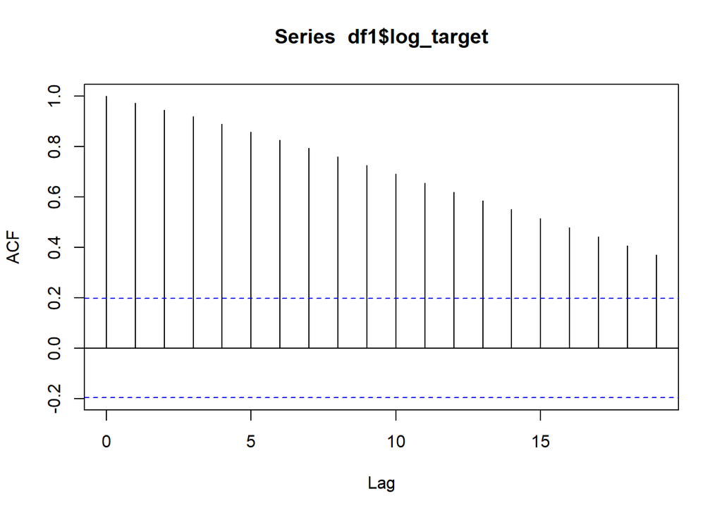

```r
acf( df1$log_target)
```

Adding the lagged columns:

```r
df1 <- df1 %>%
  mutate(lag1=lag(log_target,1),
         lag3=lag(log_target,3),
         lag6=lag(log_target,6),
         lag12=lag(log_target,12))

model3 <- lm(log_target~trend+as.factor(month)+lag1+lag3+lag6+lag12, df1)
summary(model3)
```

```
##
## Call:
## lm(formula = log_target ~ trend + as.factor(month) + lag1 + lag3 +
##     lag6 + lag12, data = df1)
##
## Residuals:
##       Min        1Q    Median        3Q       Max
## -0.040941 -0.010982 -0.003824  0.004579  0.123179
##
## Coefficients:
##                      Estimate Std. Error t value Pr(>|t|)
## (Intercept)         0.9090652  0.3359576   2.706  0.00855 **
## trend               0.0014854  0.0005694   2.609  0.01110 *
## as.factor(month)2  -0.0269322  0.0132037  -2.040  0.04515 *
## as.factor(month)3  -0.0280816  0.0130657  -2.149  0.03507 *
## as.factor(month)4  -0.0231484  0.0132551  -1.746  0.08513 .
## as.factor(month)5  -0.0199926  0.0132133  -1.513  0.13477
## as.factor(month)6  -0.0315233  0.0132806  -2.374  0.02036 *
## as.factor(month)7  -0.0129242  0.0133786  -0.966  0.33735
## as.factor(month)8   0.0001505  0.0132140   0.011  0.99095
## as.factor(month)9  -0.0280511  0.0135781  -2.066  0.04254 *
## as.factor(month)10 -0.0310516  0.0133326  -2.329  0.02275 *
## as.factor(month)11 -0.0333608  0.0132779  -2.513  0.01429 *
## as.factor(month)12 -0.0245915  0.0133044  -1.848  0.06877 .
## lag1                0.9240966  0.0828473  11.154  < 2e-16 ***
## lag3                0.0820764  0.1083082   0.758  0.45111
## lag6               -0.1241426  0.0785031  -1.581  0.11830
## lag12              -0.0343895  0.0477050  -0.721  0.47338
## ---
## Signif. codes:  0 '***' 0.001 '**' 0.01 '*' 0.05 '.' 0.1 ' ' 1
##
## Residual standard error: 0.02543 on 70 degrees of freedom
##   (12 observations deleted due to missingness)
## Multiple R-squared:  0.9925, Adjusted R-squared:  0.9908
## F-statistic: 579.3 on 16 and 70 DF,  p-value: < 2.2e-16
```

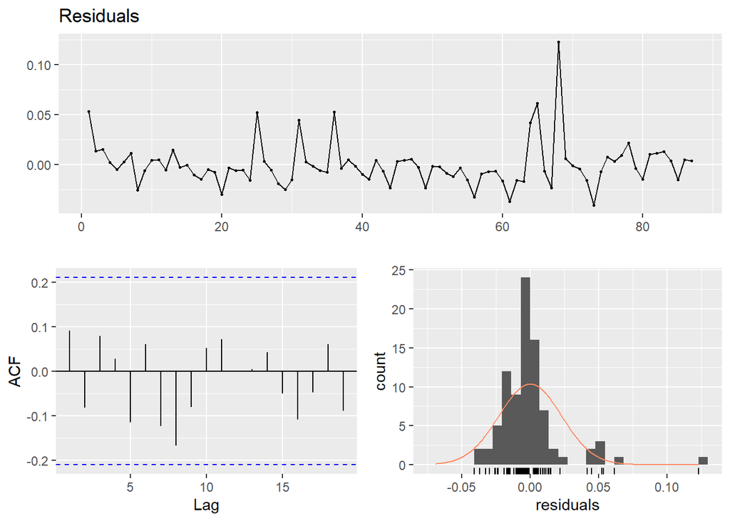

```
##
##  Breusch-Godfrey test for serial correlation of order up to 20
##
## data:  Residuals
## LM test = 18.721, df = 20, p-value = 0.54
```

```r
checkresiduals(model3)
```

Now, we solved the autocorrelation problem. But still the distribution deviates from normal, also we have a few outliers.

The most significant predictor in this model is lag1.

### 2.4.4 Trial 4

```r
df1 <- subset(df1, select=-c(lag3,lag6,lag12))
model4 <- lm(log_target~.-Date-cpi_alcohol_tobacco-month+as.factor(month), df1)
summary(model4)
```

```
##
## Call:
## lm(formula = log_target ~ . - Date - cpi_alcohol_tobacco - month +
##     as.factor(month), data = df1)
##
## Residuals:
##       Min        1Q    Median        3Q       Max
## -0.037920 -0.010944 -0.001484  0.005156  0.129689
##
## Coefficients:
##                                    Estimate Std. Error t value Pr(>|t|)
## (Intercept)                       4.294e-01  2.094e-01   2.051  0.04354 *
## general_economic_situation       -1.195e-03  4.305e-04  -2.776  0.00685 **
## USD_TRY                          -7.304e-03  5.687e-03  -1.284  0.20269
## import_processed_food_beverage    1.084e-07  7.512e-08   1.443  0.15291
## import_unprocessed_food_beverage -2.437e-08  3.226e-08  -0.755  0.45223
## trend                             6.095e-04  4.301e-04   1.417  0.16031
## lag1                              9.497e-01  3.724e-02  25.504  < 2e-16 ***
## as.factor(month)2                -2.868e-02  1.183e-02  -2.424  0.01761 *
## as.factor(month)3                -2.792e-02  1.199e-02  -2.329  0.02240 *
## as.factor(month)4                -1.299e-02  1.252e-02  -1.038  0.30242
## as.factor(month)5                -1.160e-02  1.252e-02  -0.927  0.35674
## as.factor(month)6                -2.182e-02  1.228e-02  -1.778  0.07923 .
## as.factor(month)7                -7.803e-03  1.255e-02  -0.622  0.53573
## as.factor(month)8                 8.291e-03  1.328e-02   0.624  0.53410
## as.factor(month)9                -1.687e-02  1.339e-02  -1.260  0.21141
## as.factor(month)10               -2.578e-02  1.240e-02  -2.079  0.04080 *
## as.factor(month)11               -2.556e-02  1.224e-02  -2.088  0.03996 *
## as.factor(month)12               -2.396e-02  1.230e-02  -1.947  0.05502 .
## ---
## Signif. codes:  0 '***' 0.001 '**' 0.01 '*' 0.05 '.' 0.1 ' ' 1
##
## Residual standard error: 0.02412 on 80 degrees of freedom
##   (1 observation deleted due to missingness)
## Multiple R-squared:  0.9938, Adjusted R-squared:  0.9924
## F-statistic: 750.2 on 17 and 80 DF,  p-value: < 2.2e-16
```

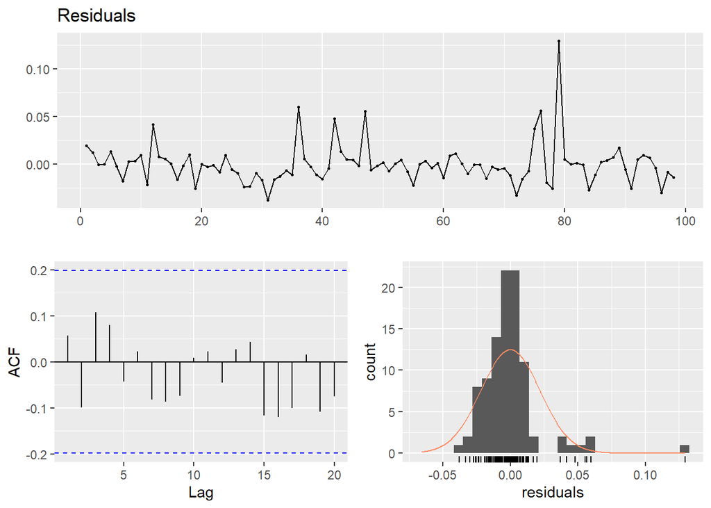

```
##
##  Breusch-Godfrey test for serial correlation of order up to 21
##
## data:  Residuals
## LM test = 18.588, df = 21, p-value = 0.6116
```

```r
checkresiduals(model4)
```

There is no serial correlation between residuals. But there are outlier values, so constant variance assumption is not satisfied. Again, the most significant predictor is the lagged target value. A very high R-squared value (0.9938) is obtained.

## 2.5 Fitted vs. Actual

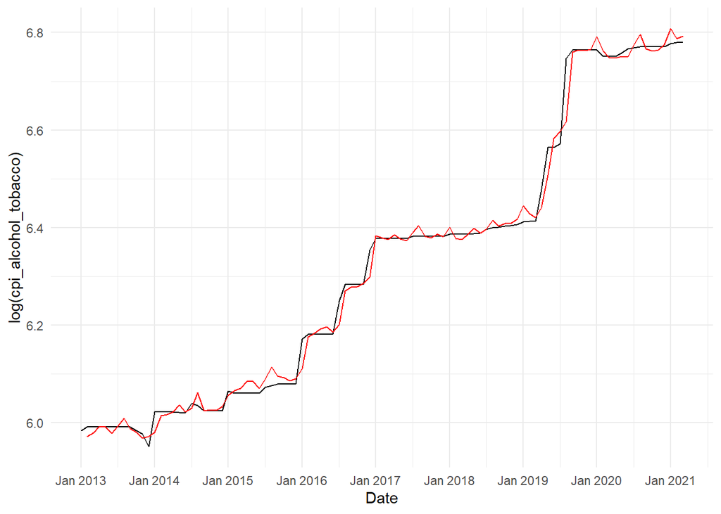

```r
ggplot(df1)+
  geom_line(aes(x=Date, y=log(cpi_alcohol_tobacco)))+
  geom_line(aes(x=Date, y=c(NA,fitted(model4))),color="red")+
  theme_minimal()+
  scale_x_yearmon(n=10)
```

## 2.6 Residuals vs. fitted

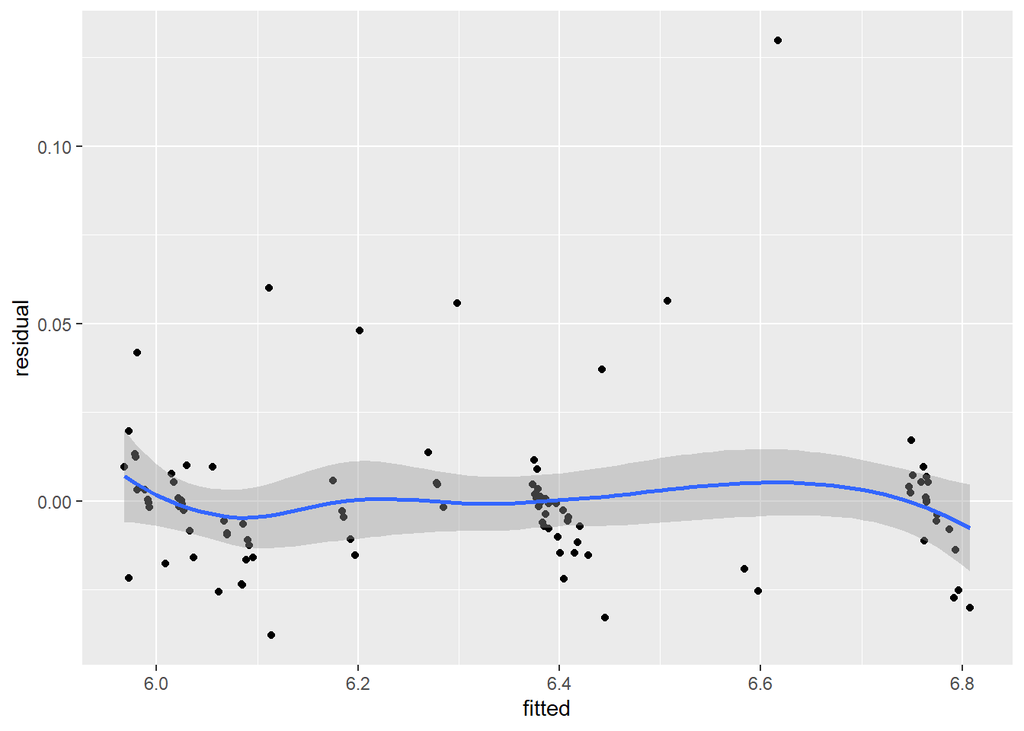

```r
df1 <- df1 %>%
  mutate(fitted=c(NA, fitted(model4)),
          residual=c(NA,residuals(model4)))

ggplot(df1, aes(x=fitted, y=residual))+
  geom_point()+
  geom_smooth()
```

## 2.7 Forecast

```r
data <- get_series(series = c("TP.FG.J02","TP.TG2.Y04","TP.TG2.Y11","TP.DK.USD.A.YTL","TP.ITHALATBEC.121","TP.ITHALATBEC.111"), start_date = "01-04-2021", end_date = "01-04-2021")
df <- data$items[,-8]
df2 <- df %>%
  mutate(Date=as.yearmon(Tarih, "%Y-%m"),
         cpi_alcohol_tobacco=as.numeric(TP_FG_J02),
         general_economic_situation=as.numeric(TP_TG2_Y04),
         USD_TRY=as.numeric(TP_DK_USD_A_YTL),
         import_processed_food_beverage=as.numeric(TP_ITHALATBEC_121),
         import_unprocessed_food_beverage=as.numeric(TP_ITHALATBEC_111)) %>%
  select(Date:import_unprocessed_food_beverage)

fc1 <-forecast(df1$import_processed_food_beverage)
fc2 <-forecast(df1$import_unprocessed_food_beverage)
df2 <- df2%>%
  mutate(
    log_target=NA,
    trend=100,
    month=4,
    lag1=6.779547,
    import_processed_food_beverage=fc1$mean[1],
    import_unprocessed_food_beverage=fc2$mean[1]
  )

exp(predict(model4, newdata = df2))
```

```
##        1
## 899.7639
```

# 3 Conclusion

In this homework, the data of CPI for alcoholic beverages and tobacco is analyzed and an autoregressive time series regression is built. Even the simple models were sufficient to build a model with a quite high R-squared value. But in simpler models, residuals are autocorrelated. By adding independent variables and lagged target values, I managed to get rid of the autocorrelation of residuals and obtained a very high R-squared value. But even in that case there were outlier residuals, which I could not manage to eliminate.

My forecast for the 04-2021 is 899.7639. By the time I submit the homework, CPI for alcoholic beverages and tobacco value is already announced as 886.09, which proves my model overestimated the target variable.